# Notebook 1: Overview and Data

### What we'll do here

- Give a short overview of the full project pipeline
- Describe what each of the following notebooks does
- Describe the data sources used in the project
- Summarize the labelling workflow
- Define the four target types in the dataset
- Show example target images
- Give a snapshot of the labelled dataset
- 1.1 Overview
- 1.2 Notebook Summary
- 1.3 Data Collection
- 1.4 Labelling Strategy
- 1.5 Target Summary
- 1.6 Dataset Snapshot

## 1.1 Overview

This project builds an end-to-end pipeline for analysing paper shooting targets from smartphone photos. We collected real-world images from Skovshoved Skytteforening and expanded the set with open-source images from Roboflow Universe, then labelled them for both target type and bullet-hole detection.

The final system combines a ResNet-18 classifier (target type prediction) with a two-stage RF-DETR detector (target localisation + bullet-hole detection). Explainable AI methods (RISE and LIME) are used to inspect what the models rely on, and the full pipeline is deployed as a Hugging Face Space.

The four course topics covered in this project are Computer Vision, Transfer Learning, Deep Learning, and Explainable AI.

Live demo: https://huggingface.co/spaces/Benyla1/aba-target-detector

## 1.2 Notebook Summary

The four notebooks together form an end-to-end pipeline from a raw smartphone photo of a paper target to a final, explained prediction.

### Notebook 1: Overview and Data

This notebook. Introduces the project, describes the dataset and labelling workflow, and defines the four target types.

### Notebook 2: Target Classification

**First step in the pipeline.** Predicts which target type a photo shows using a fine-tuned ResNet-18. A BiLSTM-on-binary-strings approach is also presented for comparison.

### Notebook 3: Bullet Hole Identification

**Core detection system.** A two-stage RF-DETR pipeline — Stage 1 locates the target in the full image, Stage 2 detects bullet holes and `black_contour` inside the cropped target.

### Notebook 4: Explainable AI

**Inspects what the Notebook 3 models rely on.** Uses RISE and LIME (two model-agnostic methods) to produce saliency maps for both detection stages.

## 1.3 Data Collection

At the start of the project, we contacted Skovshoved Skytteforening to collect real-world images of shooting targets and bullet holes.

We received around 122 images from Skovshoved Skytteforening, which served as the starting point for the dataset. To expand it, we added an open-source collection from Roboflow Universe. Bullet Hole Object Detection Dataset with 1,243 images, giving us a larger and more suitable set of images for annotation and model development.

## 1.4 Labelling Strategy

In this project, we combine manual labelling with semi-supervised model-assisted labelling. The different target types were labelled manually using a Python script, while the bullet holes were annotated through an iterative workflow with Roboflow and RF-DETR. Transfer learning allowed the model to detect most bullet holes early on, after which we manually corrected missed detections and refined the annotations.

The dataset contains four target categories. Target Types 3 and 4 are not included in training because they contain only 8 and 5 samples, respectively, making the class distribution too imbalanced. For the MVP, we therefore focus on classifying Target Type 1 and Target Type 2, while still showing how the approach could be extended to more target types with additional data.

## 1.5 Target Summary

Target 2 is shown using a real-world example in the gallery below.

| Target | Rings | Scoring range | Visible numbers |
| --- | --- | --- | --- |
| Target 1 | 10 | 1-10 | 9 |
| Target 2 | 11 | 1-11 | 8 |
| Target 3 | 8 | 3-11 | 8 |
| Target 4 | 11 | 1-11 | 5 |

## 1.6 Dataset Snapshot

The current label file `data/target_labels.csv` contains **1,313 labelled samples**. The image folder contains **1,317 image files**, so **4 images** are currently unlabelled.

| Target | Samples | Share of labelled set |
| --- | --- | --- |
| Target 1 | 459 | 35.0% |
| Target 2 | 841 | 64.1% |
| Target 3 | 8 | 0.6% |
| Target 4 | 5 | 0.4% |

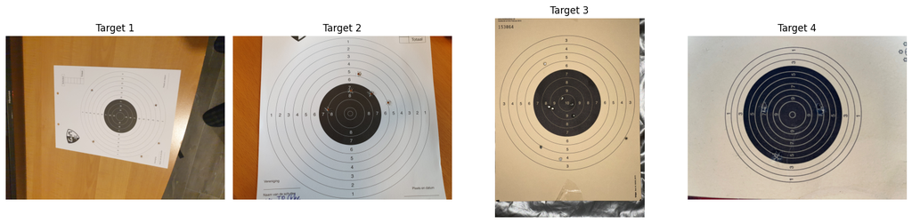

```python
import matplotlib.pyplot as plt

images = [
    ("Target 1", "data/images/1_0002-13-04-2023_API_v1_jpg.rf.myJ1hGhB01ETs4YTl2MZ.jpg"),
    ("Target 2", "data/images/20200923_130907_jpg.rf.jLuXLWJV99CQUoxq2qy2.jpg"),
    ("Target 3", "data/images/IMG_1606_jpg.rf.kVbZUa3Xq25QNBgGrsWA.jpg"),
    ("Target 4", "data/images/IMG_0054_nobg_10dg_jpg.rf.vnZ4U3STQdU27E0VdbTo.jpg"),
]

fig, axes = plt.subplots(1, len(images), figsize=(16, 4))
for ax, (title, path) in zip(axes, images):
    ax.imshow(plt.imread(path))
    ax.set_title(title)
    ax.axis("off")

plt.tight_layout()
```